# Create ROC curves in R

Thomas Evangelidis

20/10/2019

Paste below all your score files. The first two columns must be the molname and the score (**the lowest score the better, not the opposite!**). The code will ignore the rest of the columns, if they exist.

```r
RESULTS_FILES = c("data/SF1.scores",
                  "data/SF2.scores",
                  "data/SF3.scores",
                  "data/SF4.scores",
                  "data/SF5.scores"
)
```

Paste below the file with molecular bioactivities of all molecules. First column must be the molname and the second its bioactivity (1 or 0).

```r
ACTIVITIES_FILE = "data/activities"
```

Write the names that will be shown in the legend.

```r
NAMES <- c("Scoring Function 1", "Sscoring Function 2", "Scoring Function 3", "Scoring Function 4",
           "Scoring Function 5")
```

Define (i) a function to find the molnames that were scored successfully by all given scoring functions, and (ii) a function to read a score file and a file with the bioactivity of each molecule (0 or 1).

```r
common_molnames <- function(RESULTS_FILES) {
  "
  A function to find the molnames that are common in all score files in order to compare the scoring
  functions properly.
  "
  x = read.table(RESULTS_FILES[1], header = TRUE)
  colnames(x)[1] = "molname"  ; # add a column header and operate on x$molname, otherwise 'inersect' fails!
  x$molname <- tolower(x$molname)
  valid_molnames <- unique(sort(x$molname)) ; # unique molnames
  for (i in 2:length(RESULTS_FILES)) {
    x = read.table(RESULTS_FILES[i], header = TRUE)
    colnames(x)[1] = "molname"
    x$molname <- tolower(x$molname)
    valid_molnames <- intersect(valid_molnames, x$molname)
  }
  return(valid_molnames)
}
```

```r
count_actives_inactives <- function(ACTIVITIES_FILE, valid_molnames) {
  a = read.table(ACTIVITIES_FILE)
  colnames(a)[1] = "molname"
  colnames(a)[2] = "label"
  a$molname <- tolower(a$molname)
  actives <- a$molname[a$label==1]
  inactives <- a$molname[a$label==0]
  active_num <- length(actives[actives %in% valid_molnames])
  inactive_num <- length(inactives[actives %in% valid_molnames])
  paste("The molecules that have been scored by all scoring functions consist of", active_num, "actives",
        " and", inactive_num, "inactives.")
  num <- list(actives=active_num, inactives=inactive_num)
  return(num)
}
```

```r
read_scores <- function(RESULTS_FILE, ACTIVITIES_FILE, valid_molnames) {
"
  The valid_molnames list ensures that only the molnames that were scored by all scoring functions will
  be considered.
"
  x = read.table(RESULTS_FILE, header = TRUE)
  colnames(x)[1] = "molname"
  colnames(x)[2] = "score"
  x$molname <- tolower(x$molname)
  # ignore the other columns
  score_dict = hash()
  for (i in seq(1, nrow(x))) { score_dict[x[i,1]] <- x[i,2] }

  a = read.table(ACTIVITIES_FILE)
  colnames(a)[1] = "molname"
  colnames(a)[2] = "label"
  a$molname <- tolower(a$molname)
  label_dict = hash()
  for (i in seq(1, nrow(a))) { label_dict[a[i,1]] <- a[i,2] }
  scores <- rep(0, length(valid_molnames))
  labels <- rep("", length(valid_molnames))  ; # initialize labels to a list of size(scores) but without contents
  i = 1
  for (molname in valid_molnames) {
    scores[i] <- score_dict[[molname]]
    labels[i] <- label_dict[[molname]]
    i <- i+1
  }
  pred = prediction(-1*scores, labels)  ;# IMPORTANT: -1* because the function prediction() assumes that the highest the score the better
  return(pred)
}
```

Load the required libraries and create ROC curve plots. Adjust the font sizes (first line below).

```r
par(cex.main=2.0, cex.lab=1.5) ; # <== CHANGE ME

library("ROCR")
library("hash")
```

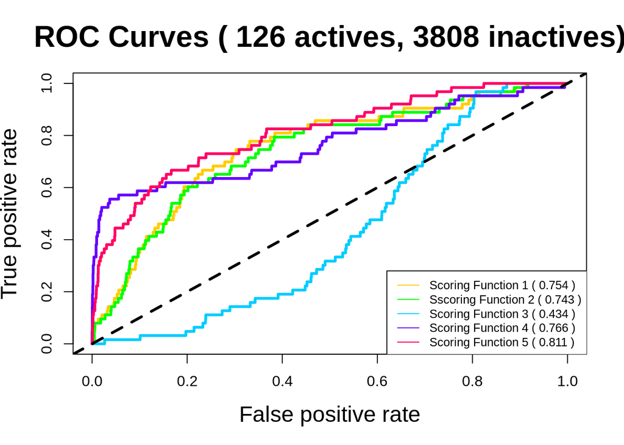

```r
COLORS <- rainbow(3*length(RESULTS_FILES))
COLORS <- COLORS[seq(3, length(COLORS), 3)]

valid_molnames <- common_molnames(RESULTS_FILES)  ; # molnames with scores by all scoring functions; only these will be used for plotting
# Count and print the number of actives and inactives that are common in all score files
num <- count_actives_inactives(ACTIVITIES_FILE, valid_molnames)
for (i in 1:length(RESULTS_FILES)) {
  pred = read_scores(RESULTS_FILES[i], ACTIVITIES_FILE, valid_molnames)
  perf = performance(pred, 'tpr', 'fpr')
  if (i==1) { plot(perf, add = FALSE, colorize = FALSE, lwd=3, col=COLORS[i],
                   main=paste("ROC Curves (", num$actives, "actives,", num$inactives, "inactives)")) }
  else { plot(perf, add = TRUE, colorize = FALSE, lwd=3, col=COLORS[i]) }
}

AUCs = rep(0, length(RESULTS_FILES))
LNAMES = rep(0, length(RESULTS_FILES))
for (i in 1:length(RESULTS_FILES)) {
  pred = read_scores(RESULTS_FILES[i], ACTIVITIES_FILE, valid_molnames)
  auc = performance(pred, measure='auc')
  AUCs[i] = sprintf("%.3f", auc@y.values)
  LNAMES[i] = paste(NAMES[i], "(", AUCs[i],")")
  # print(paste(NAMES[i], "AUC-ROC=", auc@y.values))
}

abline(a=0, b=1, lty=2, lwd=3, col="black")
# Add legend
legend(0.62, 0.28, legend=LNAMES,
       col=COLORS, lty=1, cex=0.8)
```

The number in parenthesis after each name in the legend is the area under the ROC curve.

**IMPORTANT: You will need to adjust the last line `legend(...)` to have a legend with the right names at the right position.**